# 重賞レース予測レポート【毎時自動更新中】

作成日時: 2025/11/30 10:04:52

☞ [マニュアル(pdf)](https://ryutoro-galois.github.io/keiba-predictor/manual/manual.pdf)

☞ 過去5年の同一レース結果: [2024年](https://ryutoro-galois.github.io/keiba-predictor/report/PredResult_2024y_raceDate_20241123_20241124.html), [2023年](https://ryutoro-galois.github.io/keiba-predictor/report/PredResult_2023y_raceDate_20231125_20231126.html), [2022年](https://ryutoro-galois.github.io/keiba-predictor/report/PredResult_2022y_raceDate_20221126_20221127.html), [2021年](https://ryutoro-galois.github.io/keiba-predictor/report/PredResult_2021y_raceDate_20211127_20211128.html), [2020年](https://ryutoro-galois.github.io/keiba-predictor/report/PredResult_2020y_raceDate_20201128_20201129.html)

☞ 過去4週間の別レース結果: [1週前(11/22-24)](https://ryutoro-galois.github.io/keiba-predictor/report/PredResult_2025y_raceDate_20251122_20251124.html), [2週前(11/15-16)](https://ryutoro-galois.github.io/keiba-predictor/report/PredResult_2025y_raceDate_20251115_20251116.html), [3週前(11/8-9)](https://ryutoro-galois.github.io/keiba-predictor/report/PredResult_2025y_raceDate_20251108_20251109.html), [4週前(11/1-2)](https://ryutoro-galois.github.io/keiba-predictor/report/PredResult_2025y_raceDate_20251101_20251102.html)

☞ netkeiba: [京都2歳ステークス(GⅢ)](https://race.netkeiba.com/race/shutuba.html?race_id=202508040711&rf=race_list), [ジャパンカップ(GⅠ)](https://race.netkeiba.com/race/shutuba.html?race_id=202505050812&rf=race_list), [京阪杯(GⅢ)](https://race.netkeiba.com/race/shutuba.html?race_id=202508040812&rf=race_list)

## 0. 推し馬予測 (AI予測)

### 【ラジオN杯京都2歳ステークス(GⅢ) 2025/11/29(土)】

- 本命(◎): 1-3着内確率(勝負強さ)が1位の馬
- 対抗(◯): 1-3着内確率が2-N位(20%程度以上)の中で予測タイムが最も速い馬
- 3番手(▲): 1-3着内確率が2-N位(20%程度以上)のでダークホース確率が最も高い馬
- 穴: ダークホース確率が上位1-M位(40%程度以上)の中で1-3着内確率が最も高い馬

| 推し馬 | 枠番 | 馬番 | 人気 | オッズ | 馬名 | 騎手 | 調教師 | 予測タイム(sec) | 1_順位 | 1-3着内確率(%) | 2_順位 | ﾀﾞｰｸﾎｰｽ確率(%) | 3_順位 |
| --- | --- | --- | --- | --- | --- | --- | --- | --- | --- | --- | --- | --- | --- |
| 本命(◎) | 8 | 11 | 2 | 5.7 | ウイナーズナイン | 西村淳也 | 小栗実 | 130.5 | 10.5 | 22.8 | 1 | 1.8 | 8.5 |
| 対抗(◯) | 6 | 6 | 1 | 2.2 | バルセシート | Ｃ．デムーロ | 松下武士 | 121.3 | 1.0 | 22.5 | 2 | 0.8 | 11.0 |
| 3番手(▲) | 4 | 4 | 7 | 23.5 | メイショウソラリス | 武豊 | 角田晃一 | 130.4 | 7.0 | 11.0 | 5 | 51.8 | 4.0 |
| 穴 | 1 | 1 | 11 | 51.5 | ネッタイヤライ | 松山弘平 | 矢作芳人 | 129.5 | 2.5 | 8.8 | 8 | 68.0 | 2.0 |

### 【ジャパンカップ(GⅠ) 2025/11/30(日)】

- 本命(◎): 1-3着内確率(勝負強さ)が1位の馬
- 対抗(◯): 1-3着内確率が2-N位(20%程度以上)の中で予測タイムが最も速い馬
- 3番手(▲): 1-3着内確率が2-N位(20%程度以上)のでダークホース確率が最も高い馬
- 穴: ダークホース確率が上位1-M位(40%程度以上)の中で1-3着内確率が最も高い馬

| 推し馬 | 枠番 | 馬番 | 人気 | オッズ | 馬名 | 騎手 | 調教師 | 予測タイム(sec) | 1_順位 | 1-3着内確率(%) | 2_順位 | ﾀﾞｰｸﾎｰｽ確率(%) | 3_順位 |
| --- | --- | --- | --- | --- | --- | --- | --- | --- | --- | --- | --- | --- | --- |
| 本命(◎) | 1 | 2 | 3 | 5.0 | クロワデュノール | 北村友一 | 斉藤崇史 | 140.6 | 1.5 | 45.4 | 1 | 0.7 | 13 |
| 対抗(◯) | 7 | 15 | 1 | 2.8 | マスカレードボール | Ｃ．ルメール | 手塚貴久 | 140.6 | 1.5 | 28.1 | 4 | 0.6 | 15 |
| 3番手(▲) | 8 | 18 | 6 | 16.1 | タスティエーラ | Ｄ．レーン | 堀宣行 | 145.0 | 4.0 | 40.3 | 2 | 1.6 | 10 |
| 穴 | 7 | 13 | 10 | 47.0 | ブレイディヴェーグ | Ｔ．マーカンド | 宮田敬介 | 145.2 | 5.0 | 16.4 | 8 | 42.0 | 4 |

### 【京阪杯(GⅢ) 2025/11/30(日)】

- 本命(◎): 1-3着内確率(勝負強さ)が1位の馬
- 対抗(◯): 1-3着内確率が2-N位(20%程度以上)の中で予測タイムが最も速い馬
- 3番手(▲): 1-3着内確率が2-N位(20%程度以上)のでダークホース確率が最も高い馬
- 穴: ダークホース確率が上位1-M位(40%程度以上)の中で1-3着内確率が最も高い馬

| 推し馬 | 枠番 | 馬番 | 人気 | オッズ | 馬名 | 騎手 | 調教師 | 予測タイム(sec) | 1_順位 | 1-3着内確率(%) | 2_順位 | ﾀﾞｰｸﾎｰｽ確率(%) | 3_順位 |
| --- | --- | --- | --- | --- | --- | --- | --- | --- | --- | --- | --- | --- | --- |
| 本命(◎) | 6 | 11 | 3 | 7.9 | エイシンフェンサー | 川又賢治 | 吉村圭司 | 71.1 | 6 | 30.3 | 1 | 1.4 | 15 |
| 対抗(◯) | 6 | 12 | 1 | 5.2 | ナムラクララ | 武豊 | 長谷川浩大 | 67.4 | 1 | 21.4 | 4 | 0.4 | 18 |
| 3番手(▲) | 3 | 6 | 4 | 8.1 | レイピア | 鮫島克駿 | 中竹和也 | 70.6 | 4 | 24.1 | 3 | 1.4 | 14 |
| 穴 | 2 | 3 | 12 | 28.7 | ショウナンザナドゥ | 菱田裕二 | 松下武士 | 70.2 | 3 | 9.8 | 10 | 41.0 | 1 |

## 1. 予測チャート (タイム/勝負強さ)

### 【ラジオN杯京都2歳ステークス(GⅢ)】

2025/11/29(土), 08_京都, 芝右2000m

[interactive chart not shown]

### 【ジャパンカップ(GⅠ)】

2025/11/30(日), 05_東京, 芝左2400m

[interactive chart not shown]

### 【京阪杯(GⅢ)】

2025/11/30(日), 08_京都, 芝右1200m

[interactive chart not shown]

## 2. オッズモニタリング (毎時)

### 【京都2歳ステークス】

[interactive chart not shown]

### 【ジャパンカップ】

[interactive chart not shown]

### 【京阪杯】

[interactive chart not shown]

## 3. 出馬表

### 【京都2歳ステークス 2025/11/29(土) 】

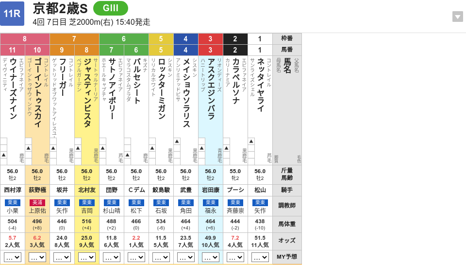

### 【ジャパンカップ 2025/11/30(日) 】

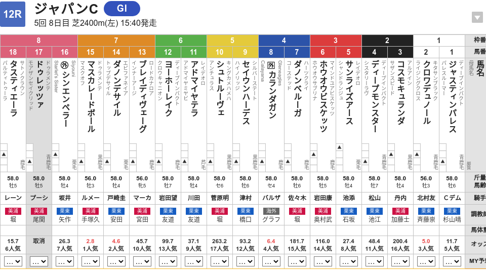

### 【京阪杯 2025/11/30(日) 】

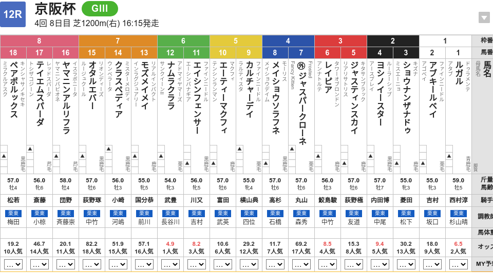

## 4. 単勝予測結果

### 【ラジオN杯京都2歳ステークス(GⅢ) 2025/11/29(土)】

| 枠番 | 馬番 | 人気 | オッズ | 馬名 | 騎手 | 調教師 | 予測タイム(sec) | 1_順位 | 1-3着内確率(%) | 2_順位 | ﾀﾞｰｸﾎｰｽ確率(%) | 3_順位 |
| --- | --- | --- | --- | --- | --- | --- | --- | --- | --- | --- | --- | --- |
| 1 | 1 | 11 | 51.5 | ネッタイヤライ | 松山弘平 | 矢作芳人 | 129.5 | 2.5 | 8.8 | 8 | 68.0 | 2.0 |
| 2 | 2 | 4 | 7.2 | カラペルソナ | Ａ．プーシャン | 斉藤崇史 | 130.4 | 6.0 | 13.7 | 4 | 1.7 | 10.0 |
| 3 | 3 | 10 | 49.9 | アスクエジンバラ | 岩田康誠 | 福永祐一 | 129.5 | 2.5 | 8.8 | 9 | 69.0 | 1.0 |
| 4 | 4 | 7 | 23.5 | メイショウソラリス | 武豊 | 角田晃一 | 130.4 | 7.0 | 11.0 | 5 | 51.8 | 4.0 |
| 5 | 5 | 5 | 11.5 | ロックターミガン | 鮫島克駿 | 石坂公一 | 130.5 | 8.5 | 9.7 | 6 | 1.9 | 7.0 |
| 6 | 6 | 1 | 2.2 | バルセシート | Ｃ．デムーロ | 松下武士 | 121.3 | 1.0 | 22.5 | 2 | 0.8 | 11.0 |
| 6 | 7 | 6 | 11.8 | サトノアイボリー | 団野大成 | 杉山晴紀 | 130.5 | 8.5 | 9.1 | 7 | 1.9 | 6.0 |
| 7 | 8 | 9 | 25.0 | ジャスティンビスタ | 北村友一 | 吉岡辰弥 | 130.3 | 4.5 | 8.1 | 11 | 53.5 | 3.0 |
| 7 | 9 | 8 | 24.0 | フリーガー | 坂井瑠星 | 矢作芳人 | 130.3 | 4.5 | 8.8 | 10 | 51.5 | 5.0 |
| 8 | 10 | 3 | 6.2 | ゴーイントゥスカイ | 荻野極 | 上原佑紀 | 130.5 | 10.5 | 16.7 | 3 | 1.8 | 8.5 |

[output cut: 1 more lines]

### 【ジャパンカップ(GⅠ) 2025/11/30(日)】

| 枠番 | 馬番 | 人気 | オッズ | 馬名 | 騎手 | 調教師 | 予測タイム(sec) | 1_順位 | 1-3着内確率(%) | 2_順位 | ﾀﾞｰｸﾎｰｽ確率(%) | 3_順位 |
| --- | --- | --- | --- | --- | --- | --- | --- | --- | --- | --- | --- | --- |
| 1 | 1 | 5 | 11.7 | ジャスティンパレス | Ｃ．デムーロ | 杉山晴紀 | 152.3 | 15.0 | 37.1 | 3 | 0.7 | 14 |
| 1 | 2 | 3 | 5.0 | クロワデュノール | 北村友一 | 斉藤崇史 | 140.6 | 1.5 | 45.4 | 1 | 0.7 | 13 |
| 2 | 3 | 16 | 203.0 | コスモキュランダ | 丹内祐次 | 加藤士津八 | 155.1 | 17.0 | 4.1 | 17 | 34.1 | 5 |
| 2 | 4 | 11 | 48.3 | ディープモンスター | 松山弘平 | 池江泰寿 | 152.1 | 14.0 | 8.9 | 12 | 26.9 | 8 |
| 3 | 5 | 8 | 28.0 | サンライズアース | 池添謙一 | 石坂公一 | 147.1 | 7.0 | 18.4 | 7 | 1.7 | 9 |
| 3 | 6 | 14 | 116.7 | ホウオウビスケッツ | 岩田康誠 | 奥村武 | 149.1 | 12.0 | 5.6 | 14 | 30.1 | 6 |
| 4 | 7 | 15 | 181.2 | ダノンベルーガ | 佐々木大輔 | 堀宣行 | 146.5 | 6.0 | 11.0 | 11 | 63.1 | 1 |
| 4 | 8 | 4 | 6.4 | カランダガン | Ｍ．バルザローナ | Ｆ．グラファール | 148.3 | 9.0 | 25.5 | 5 | 0.5 | 17 |
| 5 | 9 | 12 | 94.9 | セイウンハーデス | 津村明秀 | 橋口慎介 | 153.5 | 16.0 | 4.8 | 16 | 27.9 | 7 |
| 5 | 10 | 17 | 265.9 | シュトルーヴェ | 菅原明良 | 堀宣行 | 148.2 | 8.0 | 5.2 | 15 | 52.0 | 2 |

[output cut: 7 more lines]

### 【京阪杯(GⅢ) 2025/11/30(日)】

| 枠番 | 馬番 | 人気 | オッズ | 馬名 | 騎手 | 調教師 | 予測タイム(sec) | 1_順位 | 1-3着内確率(%) | 2_順位 | ﾀﾞｰｸﾎｰｽ確率(%) | 3_順位 |
| --- | --- | --- | --- | --- | --- | --- | --- | --- | --- | --- | --- | --- |
| 1 | 1 | 2 | 6.3 | ルガル | 西村淳也 | 杉山晴紀 | 73.7 | 12 | 24.6 | 2 | 0.4 | 17 |
| 1 | 2 | 9 | 17.9 | アブキールベイ | 吉村誠之助 | 坂口智康 | 70.2 | 2 | 11.6 | 8 | 1.8 | 10 |
| 2 | 3 | 12 | 28.7 | ショウナンザナドゥ | 菱田裕二 | 松下武士 | 70.2 | 3 | 9.8 | 10 | 41.0 | 1 |
| 2 | 4 | 5 | 9.5 | ヨシノイースター | 内田博幸 | 中尾秀正 | 73.9 | 14 | 7.4 | 14 | 1.6 | 11 |
| 3 | 5 | 8 | 14.7 | ジャスティンスカイ | 荻野極 | 友道康夫 | 74.1 | 16 | 13.9 | 7 | 1.4 | 16 |
| 3 | 6 | 4 | 8.1 | レイピア | 鮫島克駿 | 中竹和也 | 70.6 | 4 | 24.1 | 3 | 1.4 | 14 |
| 4 | 7 | 17 | 64.7 | ジャスパークローネ | 丸山元気 | 森秀行 | 72.7 | 10 | 4.0 | 17 | 8.5 | 8 |
| 4 | 8 | 7 | 12.0 | メイショウソラフネ | 高杉吏麒 | 石橋守 | 74.2 | 18 | 14.2 | 6 | 1.4 | 13 |
| 5 | 9 | 13 | 29.0 | カルチャーデイ | 横山典弘 | 四位洋文 | 71.7 | 8 | 8.1 | 12 | 28.5 | 4 |
| 5 | 10 | 6 | 11.3 | エーティーマクフィ | 富田暁 | 武英智 | 74.1 | 17 | 15.7 | 5 | 1.5 | 12 |

[output cut: 8 more lines]

## 5. 人気と着順の乖離率推移

### 【京都2歳ステークス_2014y_2019y】

[interactive chart not shown]

### 【ジャパンカップ_1990y_2019y】

[interactive chart not shown]

### 【京阪杯_1990y_2019y】

[interactive chart not shown]

### 【京都2歳ステークス_2014y_2019y】

| No | 開催年 | 不整合率(%) | 頭数 | 人気別着順(1-3位) | 人気別着順(全体) |
| --- | --- | --- | --- | --- | --- |
| 6 | 2019 | 10.5 | 9頭 | 1-2-3 | 1\|2\|3\|6\|8\|5\|9\|7\|4 |
| 5 | 2018 | 13.7 | 9頭 | 1-4-2 | 1\|4\|2\|3\|5\|6\|8\|7\|9 |
| 4 | 2017 | 36.1 | 9頭 | 2-1-5 | 2\|1\|5\|7\|6\|9\|4\|3\|8 |
| 3 | 2016 | 41.0 | 10頭 | 3-1-6 | 3\|1\|6\|8\|7\|2\|9\|4\|10\|5 |
| 2 | 2015 | 45.7 | 12頭 | 3-5-1 | 3\|5\|1\|7\|4\|2\|10\|6\|9\|8\|11\|12 |
| 1 | 2014 | 67.3 | 8頭 | 6-2-5 | 6\|2\|5\|4\|7\|3\|1\|8 |

### 【ジャパンカップ_1990y_2019y】

| No | 開催年 | 不整合率(%) | 頭数 | 人気別着順(1-3位) | 人気別着順(全体) |
| --- | --- | --- | --- | --- | --- |
| 30 | 2019 | 58.8 | 15頭 | 3-5-2 | 3\|5\|2\|12\|4\|14\|9\|7\|8\|6\|1\|15\|11\|10\|13 |
| 29 | 2018 | 20.1 | 14頭 | 1-4-2 | 1\|4\|2\|5\|8\|3\|14\|10\|9\|7\|6\|11\|12\|13 |
| 28 | 2017 | 37.3 | 17頭 | 5-2-1 | 5\|2\|1\|6\|10\|8\|4\|12\|9\|3\|7\|11\|16\|14\|13\|15\|17 |
| 27 | 2016 | 30.9 | 17頭 | 1-5-6 | 1\|5\|6\|3\|2\|8\|16\|14\|7\|13\|12\|9\|4\|10\|17\|11\|15 |
| 26 | 2015 | 44.7 | 18頭 | 4-7-1 | 4\|7\|1\|17\|5\|6\|13\|3\|18\|2\|9\|15\|14\|11\|16\|10\|12\|8 |
| 25 | 2014 | 46.6 | 17頭 | 4-3-6 | 4\|3\|6\|1\|2\|12\|8\|9\|5\|13\|7\|10\|17\|16\|14\|15\|18 |
| 24 | 2013 | 46.4 | 17頭 | 1-7-11 | 1\|7\|11\|4\|13\|6\|9\|5\|10\|3\|8\|16\|15\|17\|2\|14\|12 |
| 23 | 2012 | 30.7 | 17頭 | 3-1-2 | 3\|1\|2\|6\|4\|10\|8\|13\|5\|11\|15\|12\|7\|17\|14\|9\|16 |
| 22 | 2011 | 43.9 | 16頭 | 2-6-14 | 2\|6\|14\|11\|7\|1\|10\|5\|9\|12\|8\|13\|4\|15\|16\|3 |
| 21 | 2010 | 43.6 | 18頭 | 4-1-8 | 4\|1\|8\|7\|3\|11\|6\|5\|16\|9\|18\|10\|15\|2\|17\|12\|13\|14 |

[output cut: 20 more lines]

### 【京阪杯_1990y_2019y】

| No | 開催年 | 不整合率(%) | 頭数 | 人気別着順(1-3位) | 人気別着順(全体) |
| --- | --- | --- | --- | --- | --- |
| 30 | 2019 | 43.9 | 17頭 | 2-3-7 | 2\|3\|7\|6\|4\|17\|5\|1\|12\|15\|13\|16\|11\|14\|10\|8\|18 |
| 29 | 2018 | 42.0 | 18頭 | 1-12-11 | 1\|12\|11\|5\|8\|13\|7\|17\|14\|3\|16\|15\|9\|6\|2\|10\|18\|4 |
| 28 | 2017 | 57.3 | 15頭 | 9-6-14 | 9\|6\|14\|8\|10\|12\|5\|16\|1\|4\|3\|11\|15\|7\|13 |
| 27 | 2016 | 47.8 | 18頭 | 2-3-6 | 2\|3\|6\|10\|17\|8\|9\|7\|11\|4\|16\|5\|14\|1\|18\|12\|13\|15 |
| 26 | 2015 | 27.4 | 15頭 | 4-1-5 | 4\|1\|5\|2\|3\|12\|13\|8\|7\|9\|6\|14\|11\|10\|15 |
| 25 | 2014 | 46.3 | 18頭 | 5-11-15 | 5\|11\|15\|2\|16\|3\|7\|6\|1\|18\|12\|10\|17\|4\|8\|9\|14\|13 |
| 24 | 2013 | 28.5 | 17頭 | 7-8-10 | 7\|8\|10\|1\|4\|13\|2\|12\|3\|5\|16\|11\|14\|6\|9\|17\|15 |
| 23 | 2012 | 34.4 | 18頭 | 10-1-12 | 10\|1\|12\|3\|7\|13\|4\|15\|8\|5\|2\|9\|11\|16\|6\|14\|18\|17 |
| 22 | 2011 | 23.7 | 15頭 | 1-3-5 | 1\|3\|5\|12\|9\|2\|4\|6\|11\|10\|7\|14\|13\|15\|8 |
| 21 | 2010 | 44.1 | 18頭 | 2-13-5 | 2\|13\|5\|6\|4\|7\|16\|12\|18\|1\|11\|14\|15\|8\|9\|10\|17\|3 |

[output cut: 20 more lines]

## 6. 1-3番人気馬の着順分類予測

### 【京都2歳ステークス】

| 分類 | 凡例 | 発生確率(%) | 当該レース | 当該レースランク | 直近1年間 |
| --- | --- | --- | --- | --- | --- |
| 1: 1番人気のみ (1_pop1) | 1 \| * \| * | 16.8 | 0.00 | 1.11 | 0.00 |
| 4: 1,2番人気のみ (4_pop12) | 1 \| 2 \| * | 16.2 | 0.89 | 1.25 | 0.00 |
| 8: 1,2,3番人気すべて着外 (8_darkhorse) | * \| * \| * | 14.0 | 0.00 | 0.92 | 0.00 |
| 5: 1,3番人気のみ (5_pop13) | 1 \| 3 \| * | 13.7 | 0.75 | 1.05 | 0.00 |
| 7: 1,2,3番人気すべて着内 (7_pop123) | 1 \| 2 \| 3 | 11.1 | 0.20 | 0.85 | 0.33 |
| 6: 2,3番人気のみ (6_pop23) | 2 \| 3 \| * | 9.6 | 0.00 | 0.44 | 0.14 |
| 2: 2番人気のみ (2_pop2) | 2 \| * \| * | 9.5 | 1.04 | 4.32 | 0.00 |
| 3: 3番人気のみ (3_pop3) | 3 \| * \| * | 9.1 | 0.00 | 1.40 | 0.00 |

### 【ジャパンカップ】

| 分類 | 凡例 | 発生確率(%) | 当該レース | 当該レースランク | 直近1年間 |
| --- | --- | --- | --- | --- | --- |
| 4: 1,2番人気のみ (4_pop12) | 1 \| 2 \| * | 16.3 | 0.81 | 0.81 | 0.00 |
| 1: 1番人気のみ (1_pop1) | 1 \| * \| * | 15.8 | 0.69 | 0.69 | 0.00 |
| 5: 1,3番人気のみ (5_pop13) | 1 \| 3 \| * | 15.6 | 5.38 | 5.38 | 0.00 |
| 8: 1,2,3番人気すべて着外 (8_darkhorse) | * \| * \| * | 14.2 | 2.49 | 2.49 | 0.00 |
| 6: 2,3番人気のみ (6_pop23) | 2 \| 3 \| * | 11.1 | 0.55 | 0.55 | 0.17 |
| 2: 2番人気のみ (2_pop2) | 2 \| * \| * | 10.6 | 0.74 | 0.74 | 0.00 |
| 3: 3番人気のみ (3_pop3) | 3 \| * \| * | 8.6 | 2.97 | 2.97 | 0.00 |
| 7: 1,2,3番人気すべて着内 (7_pop123) | 1 \| 2 \| 3 | 7.7 | 0.68 | 0.68 | 0.23 |

### 【京阪杯】

| 分類 | 凡例 | 発生確率(%) | 当該レース | 当該レースランク | 直近1年間 |
| --- | --- | --- | --- | --- | --- |
| 1: 1番人気のみ (1_pop1) | 1 \| * \| * | 16.7 | 0.83 | 1.10 | 0.00 |
| 4: 1,2番人気のみ (4_pop12) | 1 \| 2 \| * | 16.5 | 1.45 | 1.27 | 0.00 |
| 8: 1,2,3番人気すべて着外 (8_darkhorse) | * \| * \| * | 14.5 | 0.72 | 0.95 | 0.00 |
| 5: 1,3番人気のみ (5_pop13) | 1 \| 3 \| * | 13.9 | 1.22 | 1.07 | 0.00 |
| 6: 2,3番人気のみ (6_pop23) | 2 \| 3 \| * | 12.0 | 0.42 | 0.55 | 0.18 |
| 2: 2番人気のみ (2_pop2) | 2 \| * \| * | 9.8 | 0.00 | 4.45 | 0.00 |
| 3: 3番人気のみ (3_pop3) | 3 \| * \| * | 9.4 | 1.09 | 1.45 | 0.00 |
| 7: 1,2,3番人気すべて着内 (7_pop123) | 1 \| 2 \| 3 | 7.1 | 0.00 | 0.55 | 0.21 |

## 7. 3連複予測結果

### 【ラジオN杯京都2歳ステークス(GⅢ) 2025/11/29(土)】

| 分類 | 馬番 | 枠番 | 人気 | 平均予測タイム(sec) | 1-3着内確率(%) | ﾀﾞｰｸﾎｰｽ確率(%) | 馬名 | 騎手 | 調教師 |
| --- | --- | --- | --- | --- | --- | --- | --- | --- | --- |
| 4: 1,2番人気のみ (4_pop12) | 6-11-2 | 6-8-2 | 1-2-8 | 127.43 | 0.26 | 0.01 | バルセシート \| ウイナーズナイン \| カラペルソナ | Ｃ．デムーロ \| 西村淳也 \| Ａ．プーシャン | 松下武士 \| 小栗実 \| 斉藤崇史 |
| 4: 1,2番人気のみ (4_pop12) | 6-11-4 | 6-8-4 | 1-2-4 | 127.73 | 0.25 | 0.00 | バルセシート \| ウイナーズナイン \| メイショウソラリス | Ｃ．デムーロ \| 西村淳也 \| 武豊 | 松下武士 \| 小栗実 \| 角田晃一 |
| 4: 1,2番人気のみ (4_pop12) | 6-11-9 | 6-8-7 | 1-2-7 | 127.53 | 0.25 | 0.01 | バルセシート \| ウイナーズナイン \| フリーガー | Ｃ．デムーロ \| 西村淳也 \| 坂井瑠星 | 松下武士 \| 小栗実 \| 矢作芳人 |
| 4: 1,2番人気のみ (4_pop12) | 6-11-10 | 6-8-8 | 1-2-5 | 127.73 | 0.25 | 0.00 | バルセシート \| ウイナーズナイン \| ゴーイントゥスカイ | Ｃ．デムーロ \| 西村淳也 \| 荻野極 | 松下武士 \| 小栗実 \| 上原佑紀 |
| 7: 1,2,3番人気すべて着内 (7_pop123) | 6-11-7 | 6-8-6 | 1-2-3 | 127.73 | 0.24 | 0.00 | バルセシート \| ウイナーズナイン \| サトノアイボリー | Ｃ．デムーロ \| 西村淳也 \| 団野大成 | 松下武士 \| 小栗実 \| 杉山晴紀 |
| 4: 1,2番人気のみ (4_pop12) | 6-11-1 | 6-8-1 | 1-2-9 | 127.47 | 0.22 | 0.01 | バルセシート \| ウイナーズナイン \| ネッタイヤライ | Ｃ．デムーロ \| 西村淳也 \| 松山弘平 | 松下武士 \| 小栗実 \| 矢作芳人 |
| 4: 1,2番人気のみ (4_pop12) | 6-11-5 | 6-8-5 | 1-2-6 | 127.63 | 0.21 | 0.00 | バルセシート \| ウイナーズナイン \| ロックターミガン | Ｃ．デムーロ \| 西村淳也 \| 鮫島克駿 | 松下武士 \| 小栗実 \| 石坂公一 |
| 4: 1,2番人気のみ (4_pop12) | 6-11-3 | 6-8-3 | 1-2-11 | 127.47 | 0.21 | 0.01 | バルセシート \| ウイナーズナイン \| アスクエジンバラ | Ｃ．デムーロ \| 西村淳也 \| 岩田康誠 | 松下武士 \| 小栗実 \| 福永祐一 |
| 4: 1,2番人気のみ (4_pop12) | 6-11-8 | 6-8-7 | 1-2-10 | 127.53 | 0.21 | 0.01 | バルセシート \| ウイナーズナイン \| ジャスティンビスタ | Ｃ．デムーロ \| 西村淳也 \| 北村友一 | 松下武士 \| 小栗実 \| 吉岡辰弥 |
| 1: 1番人気のみ (1_pop1) | 6-4-2 | 6-4-2 | 1-4-8 | 127.33 | 0.20 | 0.01 | バルセシート \| メイショウソラリス \| カラペルソナ | Ｃ．デムーロ \| 武豊 \| Ａ．プーシャン | 松下武士 \| 角田晃一 \| 斉藤崇史 |

[output cut: 155 more lines]

### 【ジャパンカップ(GⅠ) 2025/11/30(日)】

| 分類 | 馬番 | 枠番 | 人気 | 平均予測タイム(sec) | 1-3着内確率(%) | ﾀﾞｰｸﾎｰｽ確率(%) | 馬名 | 騎手 | 調教師 |
| --- | --- | --- | --- | --- | --- | --- | --- | --- | --- |
| 3: 3番人気のみ (3_pop3) | 2-18-1 | 1-8-1 | 3-6-7 | 145.33 | 5.88 | 0.00 | クロワデュノール \| タスティエーラ \| ジャスティンパレス | 北村友一 \| Ｄ．レーン \| Ｃ．デムーロ | 斉藤崇史 \| 堀宣行 \| 杉山晴紀 |
| 3: 3番人気のみ (3_pop3) | 2-18-5 | 1-8-3 | 3-6-8 | 144.40 | 4.86 | 0.00 | クロワデュノール \| タスティエーラ \| サンライズアース | 北村友一 \| Ｄ．レーン \| 池添謙一 | 斉藤崇史 \| 堀宣行 \| 石坂公一 |
| 3: 3番人気のみ (3_pop3) | 2-18-16 | 1-8-8 | 3-6-9 | 145.23 | 4.55 | 0.00 | クロワデュノール \| タスティエーラ \| シンエンペラー | 北村友一 \| Ｄ．レーン \| 坂井瑠星 | 斉藤崇史 \| 堀宣行 \| 矢作芳人 |
| 3: 3番人気のみ (3_pop3) | 2-18-17 | 1-8-8 | 3-6-12 | 143.87 | 4.43 | 0.01 | クロワデュノール \| タスティエーラ \| ドゥレッツァ | 北村友一 \| Ｄ．レーン \| Ａ．プーシャン | 斉藤崇史 \| 堀宣行 \| 尾関知人 |
| 5: 1,3番人気のみ (5_pop13) | 15-2-18 | 7-1-8 | 1-3-6 | 142.07 | 4.24 | 0.00 | マスカレードボール \| クロワデュノール \| タスティエーラ | Ｃ．ルメール \| 北村友一 \| Ｄ．レーン | 手塚貴久 \| 斉藤崇史 \| 堀宣行 |
| 3: 3番人気のみ (3_pop3) | 2-18-13 | 1-8-7 | 3-6-11 | 144.13 | 4.17 | 0.01 | クロワデュノール \| タスティエーラ \| ブレイディヴェーグ | 北村友一 \| Ｄ．レーン \| Ｔ．マーカンド | 斉藤崇史 \| 堀宣行 \| 宮田敬介 |
| 3: 3番人気のみ (3_pop3) | 2-8-18 | 1-4-8 | 3-4-6 | 145.10 | 4.16 | 0.00 | クロワデュノール \| カランダガン \| タスティエーラ | 北村友一 \| Ｍ．バルザローナ \| Ｄ．レーン | 斉藤崇史 \| Ｆ．グラファール \| 堀宣行 |
| 3: 3番人気のみ (3_pop3) | 2-1-5 | 1-1-3 | 3-7-8 | 146.20 | 3.67 | 0.00 | クロワデュノール \| ジャスティンパレス \| サンライズアース | 北村友一 \| Ｃ．デムーロ \| 池添謙一 | 斉藤崇史 \| 杉山晴紀 \| 石坂公一 |
| 8: 1,2,3番人気すべて着外 (8_darkhorse) | 18-1-5 | 8-1-3 | 6-7-8 | 147.67 | 3.59 | 0.00 | タスティエーラ \| ジャスティンパレス \| サンライズアース | Ｄ．レーン \| Ｃ．デムーロ \| 池添謙一 | 堀宣行 \| 杉山晴紀 \| 石坂公一 |
| 3: 3番人気のみ (3_pop3) | 2-1-16 | 1-1-8 | 3-7-9 | 147.03 | 3.44 | 0.00 | クロワデュノール \| ジャスティンパレス \| シンエンペラー | 北村友一 \| Ｃ．デムーロ \| 坂井瑠星 | 斉藤崇史 \| 杉山晴紀 \| 矢作芳人 |

[output cut: 806 more lines]

## 8. 直近の全レース情報

| No | 日付 | 競馬場 | R | 発走 | レース名 | 距離 | 頭数 | URL(netkeiba) |
| --- | --- | --- | --- | --- | --- | --- | --- | --- |
| 25 | 2025/11/30(日) | 05_東京 | 1R |  | 2歳未勝利 | 1400 | 20頭 | https://race.netkeiba.com/race/shutuba.html?race_id=202505050801&amp;rf=race_list |
| 26 | 2025/11/30(日) | 05_東京 | 2R |  | 2歳未勝利 | 1600 | 9頭 | https://race.netkeiba.com/race/shutuba.html?race_id=202505050802&amp;rf=race_list |
| 27 | 2025/11/30(日) | 05_東京 | 3R |  | 2歳未勝利 | 1600 | 10頭 | https://race.netkeiba.com/race/shutuba.html?race_id=202505050803&amp;rf=race_list |
| 28 | 2025/11/30(日) | 05_東京 | 4R |  | 2歳未勝利 | 2000 | 9頭 | https://race.netkeiba.com/race/shutuba.html?race_id=202505050804&amp;rf=race_list |
| 29 | 2025/11/30(日) | 05_東京 | 5R |  | 2歳新馬 | 1600 | 17頭 | https://race.netkeiba.com/race/shutuba.html?race_id=202505050805&amp;rf=race_list |
| 30 | 2025/11/30(日) | 05_東京 | 6R |  | 2歳新馬 | 1800 | 13頭 | https://race.netkeiba.com/race/shutuba.html?race_id=202505050806&amp;rf=race_list |
| 31 | 2025/11/30(日) | 05_東京 | 7R |  | 3歳以上1勝クラス | 1400 | 18頭 | https://race.netkeiba.com/race/shutuba.html?race_id=202505050807&amp;rf=race_list |
| 32 | 2025/11/30(日) | 05_東京 | 8R | 13:15 | ベゴニア賞 | 1600 | 9頭 | https://race.netkeiba.com/race/shutuba.html?race_id=202505050808&amp;rf=race_list |
| 33 | 2025/11/30(日) | 05_東京 | 9R | 13:50 | オリエンタル | 2000 | 10頭 | https://race.netkeiba.com/race/shutuba.html?race_id=202505050809&amp;rf=race_list |
| 34 | 2025/11/30(日) | 05_東京 | 10R | 14:25 | アプローズ賞 | 1400 | 33頭 | https://race.netkeiba.com/race/shutuba.html?race_id=202505050810&amp;rf=race_list |

[output cut: 14 more lines]